# Session 4: Homework 2

Group 29

2020-10-04

# 1 Climate change and temperature anomalies

If we wanted to study climate change, we can find data on the *Combined Land-Surface Air and Sea-Surface Water Temperature Anomalies* in the Northern Hemisphere at [NASA’s Goddard Institute for Space Studies](https://data.giss.nasa.gov/gistemp). The [tabular data of temperature anomalies can be found here](https://data.giss.nasa.gov/gistemp/tabledata_v3/NH.Ts+dSST.txt)

To define temperature anomalies you need to have a reference, or base, period which NASA clearly states that it is the period between 1951-1980.

Firstly, we need to load the file:

```r
weather <-
  read_csv("https://data.giss.nasa.gov/gistemp/tabledata_v3/NH.Ts+dSST.csv",
           skip = 1,
           na = "***")
```

Then we select the year and the months from the ‘weather’ dataset and convert it to a long format.

```r
tidyweather <- weather %>%
  select(c(Year,Jan,Feb,Mar,Apr,May,Jun,Jul,Aug,Sep,Oct,Nov,Dec))%>%
  pivot_longer(cols = 2:13, names_to = "Month", values_to = "delta")
glimpse(tidyweather)
```

```
## Rows: 1,680
## Columns: 3
## $ Year  <dbl> 1880, 1880, 1880, 1880, 1880, 1880, 1880, 1880, 1880, 1880, 1...
## $ Month <chr> "Jan", "Feb", "Mar", "Apr", "May", "Jun", "Jul", "Aug", "Sep"...
## $ delta <dbl> -0.54, -0.38, -0.26, -0.37, -0.11, -0.22, -0.23, -0.24, -0.26...
```

We observe that the dataframe has 3 variables: Year, Month, and Delta (Temperature Deviation)

## 1.1 Plotting Information

Let us plot the data using a time-series scatter plot, and add a trendline. To do that, we first need to create a new variable called `date` in order to ensure that the `delta` values are plot chronologically.

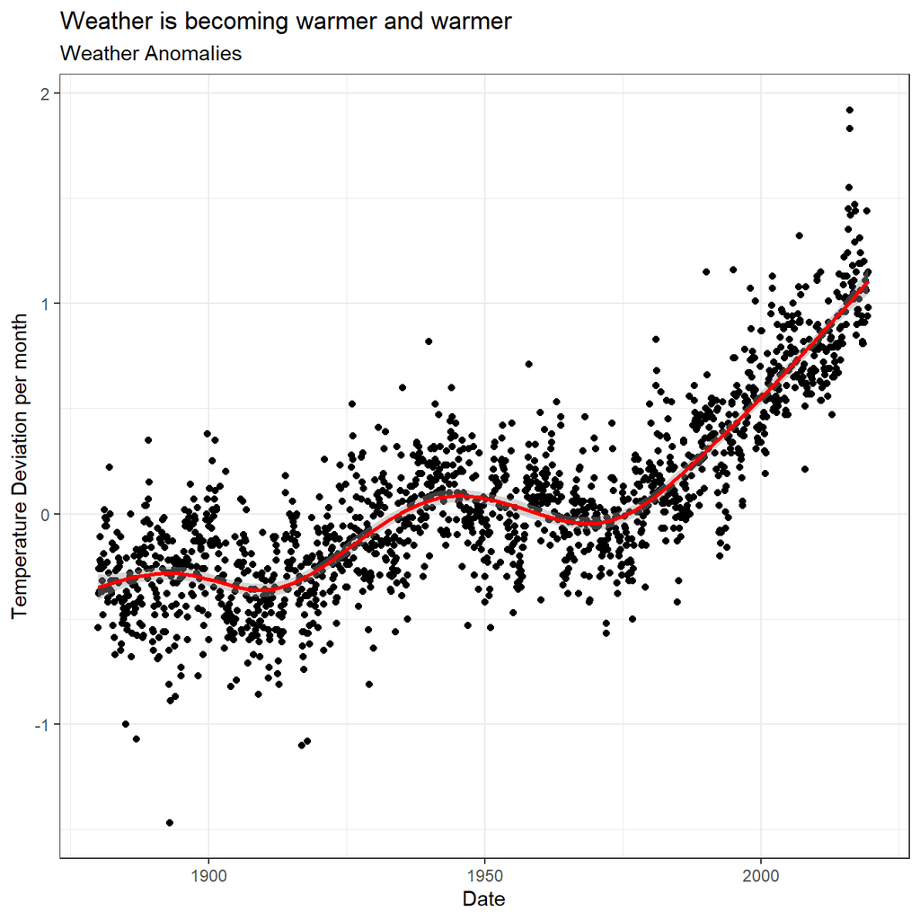

```r
tidyweather <- tidyweather %>%
  mutate(date = ymd(paste(as.character(Year), Month, "1")),
         month = month(date, label=TRUE),
         year = year(date))

ggplot(tidyweather, aes(x=date, y = delta))+
  geom_point()+
  geom_smooth(color="red") +
  theme_bw() +
  labs (
    subtitle = "Weather Anomalies",
    title = "Weather is becoming warmer and warmer"
  )+
  xlab("Date")+
  ylab("Temperature Deviation per month")
```

We create a scatter plot for each month.

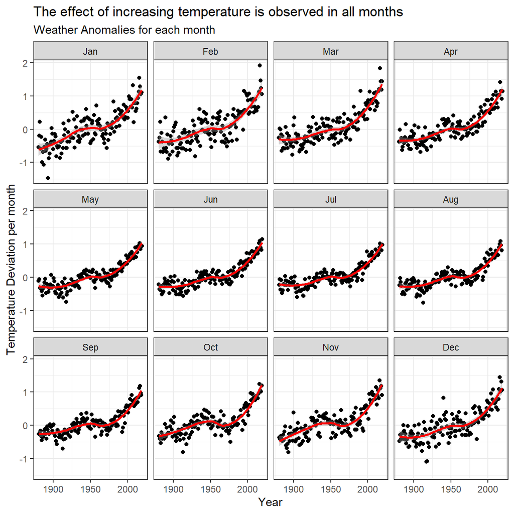

Looking at the plot we created, we observe that delta is increasing over time for all months. However, it seems that this increase is more pronounced in Winter. For instance, in October - March, the delta is closer to 1.5, whereas in the summer months it is around 1.

We would like to group the data into different time periods to study the large historical data. The most convenient way to do this is to refer to decades such as 1980s, 1990s etc. NASA calculates the temperature anomalies, as differed from the base period of 1951-1980. Thus, we create a new data frame called `comparison` that groups data in 5 time periods: 1881-1920, 1921-1950, 1951-1980, 1981-2010 and 2011-present.

```r
comparison <- tidyweather %>%
  filter(Year>= 1881) %>%
  mutate(interval = case_when(
    Year %in% c(1881:1920) ~ "1881-1920",
    Year %in% c(1921:1950) ~ "1921-1950",
    Year %in% c(1951:1980) ~ "1951-1980",
    Year %in% c(1981:2010) ~ "1981-2010",
    TRUE ~ "2011-present"
  ))
```

Now that we have the `interval` variable, we can create a density plot to study the distribution of monthly deviations (`delta`), grouped by the different time periods we are interested in. Set `fill` to `interval` to group and colour the data by different time periods.

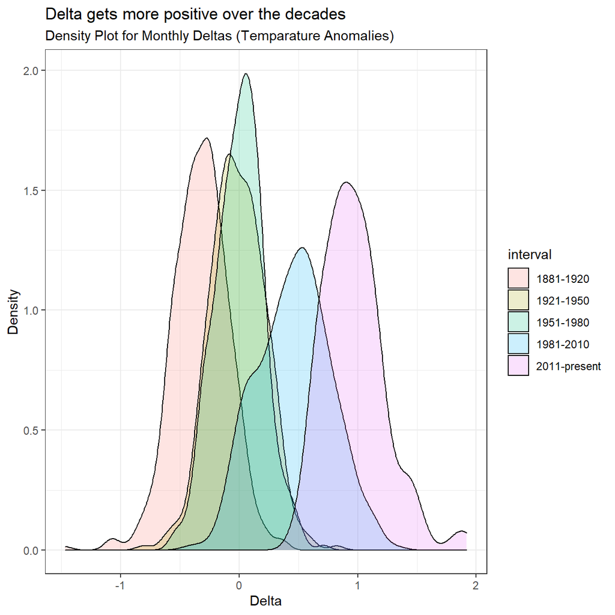

```r
ggplot(comparison, aes(x=delta, fill=interval))+
  geom_density(alpha=0.2) +
  theme_bw() +
  labs (
    title = "Delta gets more positive over the decades",
    subtitle = "Density Plot for Monthly Deltas (Temparature Anomalies)",
    y     = "Density" ,
    x= "Delta"
  )
```

So far, we have been working with monthly anomalies. However, we might be interested in average annual anomalies. We can do this by using `group_by()` and `summarise()`, followed by a scatter plot to display the result.

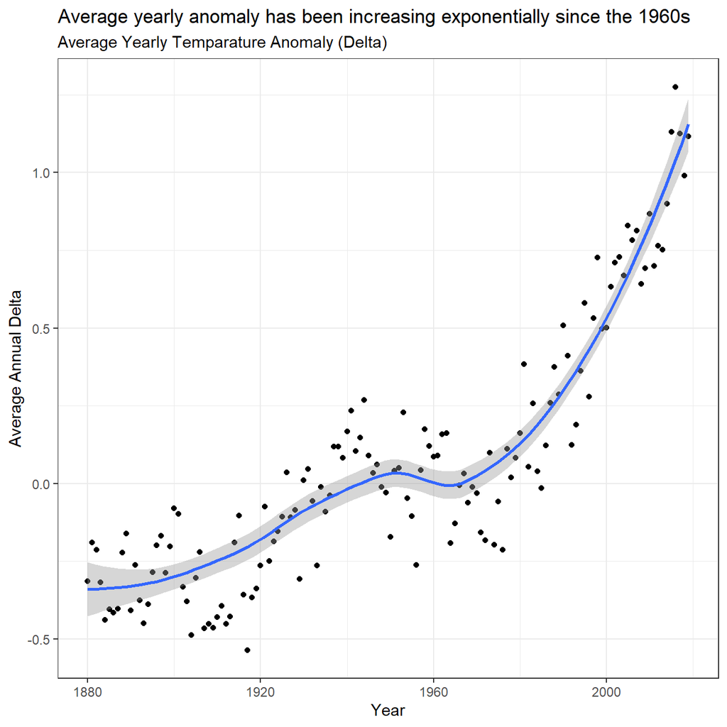

```r
avg_annual_anomaly <- tidyweather %>%
  group_by(Year) %>%
  # creating summaries for mean delta
  summarise(annual_avg_delta = mean(delta, na.rm=TRUE))

ggplot(avg_annual_anomaly, aes(x=Year, y= annual_avg_delta))+
  geom_point()+
  geom_smooth() +
  theme_bw() +
  labs (
    title="Average yearly anomaly has been increasing exponentially since the 1960s",
    subtitle = "Average Yearly Temparature Anomaly (Delta)",
    y     = "Average Annual Delta"
  )
```

## 1.2 Confidence Interval for `delta`

[NASA points out on their website](https://earthobservatory.nasa.gov/world-of-change/decadaltemp.php) that

> A one-degree global change is significant because it takes a vast amount of heat to warm all the oceans, atmosphere, and land by that much. In the past, a one- to two-degree drop was all it took to plunge the Earth into the Little Ice Age.

Now, we construct a 95% confidence interval for our data.

```r
calculate_ci <- comparison %>%
  filter(interval == "2011-present")%>%
  summarise(mean_diff=mean(delta,na.rm = TRUE),
            sd_diff=sd(delta, na.rm = TRUE),
            count_diff=n(),
            se_diff=sd_diff/sqrt(count_diff),
            t_critical = qt(0.975, count_diff-1),
            lower = mean_diff-t_critical*se_diff,
            upper = mean_diff+t_critical*se_diff)

#print out formula_CI
calculate_ci
```

```
## # A tibble: 1 x 7
##   mean_diff sd_diff count_diff se_diff t_critical lower upper
##       <dbl>   <dbl>      <int>   <dbl>      <dbl> <dbl> <dbl>
## 1     0.966   0.262        108  0.0252       1.98 0.916  1.02
```

The 95% confidence interval for delta is 0.916-1.02.

Now, we use the bootstrap method to create a confidence interval.

```r
# use the infer package to construct a 95% CI for delta

library(infer)
set.seed(1234)
data_infer <- comparison %>%
   filter(interval == "2011-present")%>%
  specify(response = delta)%>%
  generate(reps = 1000, type="bootstrap")%>%
  calculate(stat="mean")

percentile_ci <- data_infer %>%
  get_confidence_interval(level=0.95, type="percentile")

percentile_ci
```

```
## # A tibble: 1 x 2
##   lower_ci upper_ci
##      <dbl>    <dbl>
## 1    0.917     1.02
```

We have created two confidence intervals using two methods, one using our dataset and the other via bootstrapping for mean delta. The bootstrap method generates 1000 samples with replacement and approximates the distribution to estimate sample variability. The data shows us (for both methods, with the formula as well as with the infer package) that we can be 95% sure that the real mean of the population of temperature differences lies between 0.917 and 1.02.

# 2 General Social Survey (GSS)

The [General Social Survey (GSS)](http://www.gss.norc.org/) gathers data on American society in order to monitor and explain trends in attitudes, behaviours, and attributes. Many trends have been tracked for decades, so one can see the evolution of attitudes, etc in American Society.

In this assignment we analyze data from the **2016 GSS sample data**, using it to estimate values of *population parameters* of interest about US adults. The GSS sample data file has 2867 observations of 935 variables, but we are only interested in very few of these variables and you are using a smaller file.

```r
gss <- read_csv(here::here("data", "smallgss2016.csv"),
                na = c("", "Don't know",
                       "No answer", "Not applicable"))
glimpse(gss)
```

```
## Rows: 2,867
## Columns: 7
## $ emailmin <chr> "0", "30", "NA", "10", "NA", "0", "0", "NA", "0", "NA", "0...
## $ emailhr  <chr> "12", "0", "NA", "0", "NA", "2", "40", "NA", "0", "NA", "2...
## $ snapchat <chr> "NA", "No", "No", "NA", "Yes", "No", "NA", "Yes", "NA", "N...
## $ instagrm <chr> "NA", "No", "No", "NA", "Yes", "Yes", "NA", "Yes", "NA", "...
## $ twitter  <chr> "NA", "No", "No", "NA", "No", "No", "NA", "No", "NA", "No"...
## $ sex      <chr> "Male", "Male", "Male", "Female", "Female", "Female", "Mal...
## $ degree   <chr> "Bachelor", "High school", "Bachelor", "High school", "Gra...
```

We observe that many responses should not be taken into consideration, like “No Answer”, “Don’t Know”, “Not applicable”, “Refused to Answer”, thus, we merge them under `na`.

We will be creating 95% confidence intervals for population parameters. The variables we have are the following:

- hours and minutes spent on email weekly. The responses to these questions are recorded in the `emailhr` and `emailmin` variables. For example, if the response is 2.50 hours, this would be recorded as emailhr = 2 and emailmin = 30.
- `snapchat`, `instagrm`, `twitter`: whether respondents used these social media in 2016
- `sex`: Female - Male
- `degree`: highest education level attained

## 2.1 Instagram and Snapchat, by sex

We estimate the population proportion of Snapchat or Instagram users in 2016.

Firstly, we create a new variable, snap_insta that is Yes if the respondent reported using any of Snapchat (snapchat) or Instagram (instagrm), and No if not.

```r
social_media <- gss%>%
  mutate(snap_insta = if_else(snapchat == "NA" & instagrm == "NA", "NA", if_else(snapchat == "Yes" | instagrm == "Yes", "Yes", "No")))

glimpse(social_media)
```

```
## Rows: 2,867
## Columns: 8
## $ emailmin   <chr> "0", "30", "NA", "10", "NA", "0", "0", "NA", "0", "NA", ...
## $ emailhr    <chr> "12", "0", "NA", "0", "NA", "2", "40", "NA", "0", "NA", ...
## $ snapchat   <chr> "NA", "No", "No", "NA", "Yes", "No", "NA", "Yes", "NA", ...
## $ instagrm   <chr> "NA", "No", "No", "NA", "Yes", "Yes", "NA", "Yes", "NA",...
## $ twitter    <chr> "NA", "No", "No", "NA", "No", "No", "NA", "No", "NA", "N...
## $ sex        <chr> "Male", "Male", "Male", "Female", "Female", "Female", "M...
## $ degree     <chr> "Bachelor", "High school", "Bachelor", "High school", "G...
## $ snap_insta <chr> "NA", "No", "No", "NA", "Yes", "Yes", "NA", "Yes", "NA",...
```

We calculate the proportion of Yes’s for snap_insta among those who answered the question and add it to a new column.

```r
social_media_stats <- social_media %>%
  group_by(snap_insta)%>%
  count(snap_insta)%>%
  pivot_wider(names_from=snap_insta, values_from = n )%>%
  mutate(proportion_yes = Yes/(Yes+No))

social_media_stats
```

```
## # A tibble: 1 x 4
##    `NA`    No   Yes proportion_yes
##   <int> <int> <int>          <dbl>
## 1  1495   858   514          0.375
```

We observe that the proportion of people being active on either Snapchat or Instagram is 37.5%.

Using the formula for finding the Confidence Interval, we construct 95% CIs for men and women who used either Snapchat or Instagram.

```r
social_media_summary <- social_media %>%
  filter(snap_insta != "NA") %>%
  mutate(snap_insta_num = snap_insta == "Yes") %>%
  group_by(sex) %>%
  summarise(count = n(),
            mean_prob = mean(snap_insta_num),
            sd_prob = sd(snap_insta_num),
            t_critical_95 = qt(0.975, count-1),
            lower_bound = mean_prob - t_critical_95 * (sd_prob/(count)^0.5),
            upper_bound = mean_prob + t_critical_95 * (sd_prob/(count)^0.5)
            )

social_media_summary
```

```
## # A tibble: 2 x 7
##   sex    count mean_prob sd_prob t_critical_95 lower_bound upper_bound
##   <chr>  <int>     <dbl>   <dbl>         <dbl>       <dbl>       <dbl>
## 1 Female   769     0.419   0.494          1.96       0.384       0.454
## 2 Male     603     0.318   0.466          1.96       0.281       0.356
```

The confidence intervals for males and females are shown in the table above.

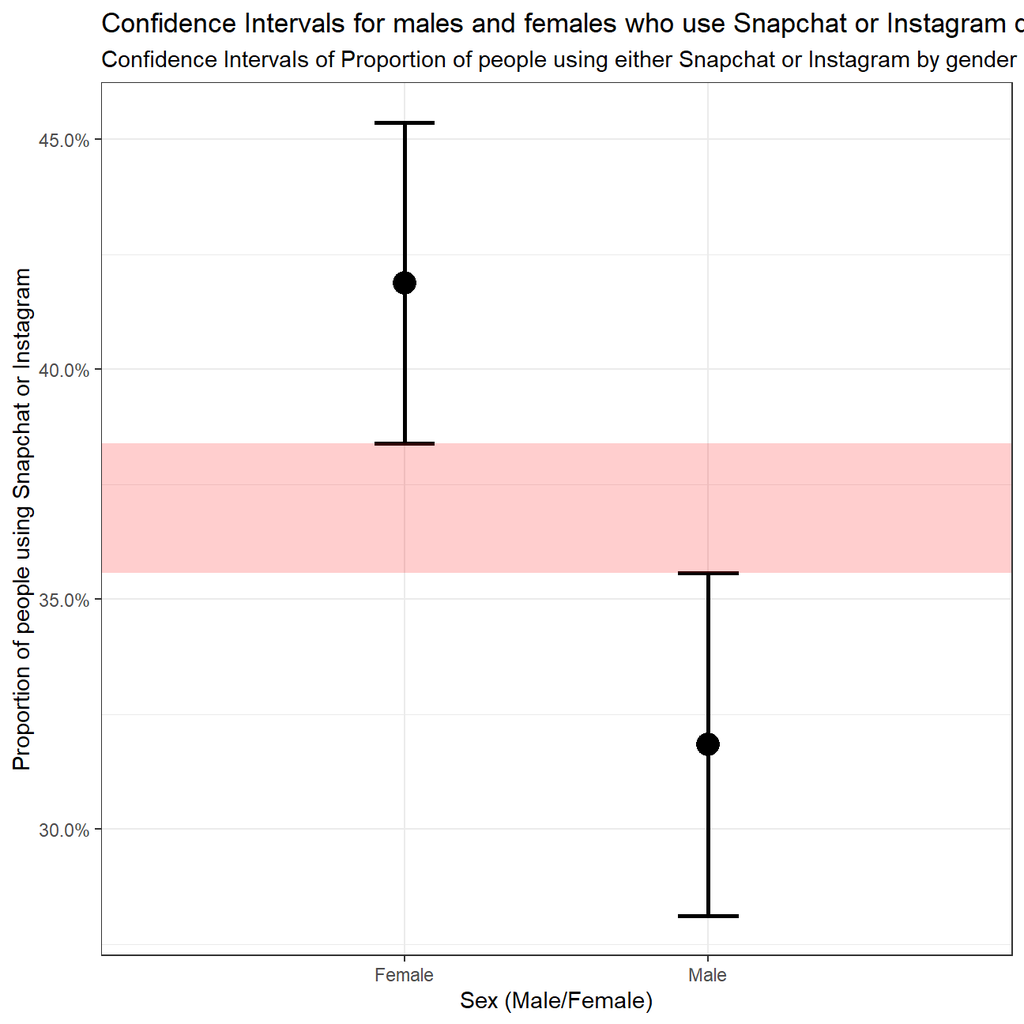

```r
ggplot(social_media_summary,
       aes(sex, mean_prob, ymin = lower_bound, ymax = upper_bound))+
  geom_errorbar(width = 0.2, size = 1) +
  geom_point(size = 5) +
  theme_bw() +
  labs(title = "Confidence Intervals for males and females who use Snapchat or Instagram do not overlap",
       subtitle = "Confidence Intervals of Proportion of people using either Snapchat or Instagram by gender",
       x="Sex (Male/Female)", y= "Proportion of people using Snapchat or Instagram") +
  scale_y_continuous(labels = scales::percent) +
  geom_rect(aes(xmin = 0, xmax = 3, ymin = social_media_summary$upper_bound[2], ymax=social_media_summary$lower_bound[1]), fill = "red", alpha = 0.1, size=0.1) +
  NULL
```

Finally, when we plot the output, we can see that the confidence intervals for females and males do not overlap considering their CIs for Snapchat or Instagram use proportions.

## 2.2 Twitter, by education level

We estimate the *population* proportion of Twitter users by education level in 2016.

There are 5 education levels in variable `degree` which, in ascneding order of years of education, are Lt high school, High School, Junior college, Bachelor, Graduate.

First, we turn `degree` from a character variable into a factor variable. Second, we create a new variable, `bachelor_graduate` that is *Yes* if the respondent has either a `Bachelor` or `Graduate` degree.

```r
twitter_population <- gss %>%
  mutate(degree = factor(degree, order = TRUE, levels = c("Lt high school", "High school", "Junior college", "Bachelor", "Graduate")),
         bachelor_graduate = if_else(degree >= "Bachelor", "Yes", "No"))

twitter_population
```

```
## # A tibble: 2,867 x 8
##    emailmin emailhr snapchat instagrm twitter sex    degree     bachelor_gradua~
##    <chr>    <chr>   <chr>    <chr>    <chr>   <chr>  <ord>      <chr>
##  1 0        12      NA       NA       NA      Male   Bachelor   Yes
##  2 30       0       No       No       No      Male   High scho~ No
##  3 NA       NA      No       No       No      Male   Bachelor   Yes
##  4 10       0       NA       NA       NA      Female High scho~ No
##  5 NA       NA      Yes      Yes      No      Female Graduate   Yes
##  6 0        2       No       Yes      No      Female Junior co~ No
##  7 0        40      NA       NA       NA      Male   High scho~ No
##  8 NA       NA      Yes      Yes      No      Female High scho~ No
##  9 0        0       NA       NA       NA      Male   High scho~ No
## 10 NA       NA      No       No       No      Male   Junior co~ No
## # ... with 2,857 more rows
```

We calculate the proportion of `bachelor_graduate` who do (Yes) and who don’t (No) use twitter.

```r
twitter_bach <- twitter_population %>%
  filter(bachelor_graduate == "Yes", twitter != "NA") %>%
  mutate(twitter_num = twitter == "Yes") %>%
  group_by(bachelor_graduate, twitter) %>%
  count()

twitter_bach
```

```
## # A tibble: 2 x 3
## # Groups:   bachelor_graduate, twitter [2]
##   bachelor_graduate twitter     n
##   <chr>             <chr>   <int>
## 1 Yes               No        375
## 2 Yes               Yes       114
```

We use the CI formula for proportions to construct two 95% CIs for `bachelor_graduate` vs whether they use (Yes) and don’t (No) use twitter.

```r
twitter_bach <- twitter_population %>%
  filter(bachelor_graduate != "NA", twitter != "NA") %>%
  mutate(twitter_num = twitter == "Yes") %>%
  group_by(bachelor_graduate, twitter) %>%
  count() %>%
  pivot_wider(names_from = twitter, values_from = n) %>%
  mutate(proportion_twitter_users = Yes /(Yes+No),
         proportion_notwitter_users = No /(Yes+No))

twitter_bach
```

```
## # A tibble: 2 x 5
## # Groups:   bachelor_graduate [2]
##   bachelor_graduate    No   Yes proportion_twitter_use~ proportion_notwitter_us~
##   <chr>             <int> <int>                   <dbl>                    <dbl>
## 1 No                  741   141                   0.160                    0.840
## 2 Yes                 375   114                   0.233                    0.767
```

```r
graduate_ci <- twitter_population %>%
  filter(twitter != "NA", bachelor_graduate != "NA") %>%
  mutate(bachelor_graduate_adj = bachelor_graduate == "Yes") %>%
  group_by(twitter) %>%
  summarize(count = n(),
            proportion_graduate = mean(bachelor_graduate_adj),
            sd_prop = sd(bachelor_graduate_adj),
            t_critical_95 = qt(0.975, count-1),
            lower_bound_95 = proportion_graduate - t_critical_95 * (sd_prop/(count)^0.5),
            upper_bound_95 = proportion_graduate + t_critical_95 * (sd_prop/(count)^0.5)
            )


graduate_ci%>%

  select(lower_bound_95,upper_bound_95)
```

```
## # A tibble: 2 x 2
##   lower_bound_95 upper_bound_95
##            <dbl>          <dbl>
## 1          0.308          0.364
## 2          0.386          0.508
```

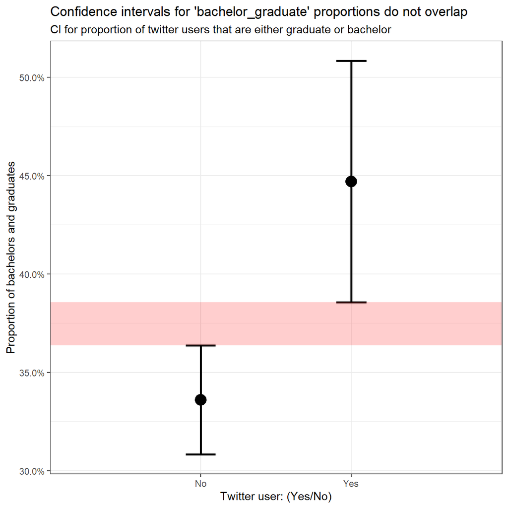

```r
ggplot(graduate_ci,
       aes(twitter, proportion_graduate, ymax = upper_bound_95, ymin = lower_bound_95))+
  geom_errorbar(aes(width = 0.2), size = 1) + #other way would be errorbar
  geom_point(size = 5) +
  theme_bw() +
  #xlim(0.2, 0.8) +
  labs(title = "Confidence intervals for 'bachelor_graduate' proportions do not overlap",
       subtitle = "CI for proportion of twitter users that are either graduate or bachelor",
       x="Twitter user: (Yes/No)", y= "Proportion of bachelors and graduates") +
  scale_y_continuous(labels = scales::percent) +
  geom_rect(aes(xmin = 0, xmax = 3, ymin = graduate_ci$upper_bound_95[1], ymax=graduate_ci$lower_bound_95[2]), fill = "red", alpha = 0.1, size=0.1) +
  NULL
```

We observe that the two confidence intervals do not overlap. This shows that there is a significant difference in education between twitter users and non-twitter users.

## 2.3 Email usage

We estimate the *population* parameter on time spent on email weekly.

We create a new variable called `email` that combines `emailhr` and `emailmin` to reports the number of minutes the respondents spend on email weekly, and then summarise it.

```r
email_pop <- gss %>%
  mutate(email_in_min = as.numeric(hours(emailhr) + minutes(emailmin),"minutes"))

email_pop %>% filter(!is.na(email_in_min)) %>%
  summarize(mean = mean(email_in_min), median = median(email_in_min))
```

```
## # A tibble: 1 x 2
##    mean median
##   <dbl>  <dbl>
## 1  417.    120
```

We visualise the distribution of this new variable.

```r
email_pop %>%
  filter(!is.na(email_in_min)) %>%
  summarize(count = n(),
            mean_email_time = mean(email_in_min, na.rm = TRUE),
            median_email_time = median(email_in_min, na.rm = TRUE))
```

```
## # A tibble: 1 x 3
##   count mean_email_time median_email_time
##   <int>           <dbl>             <dbl>
## 1  1649            417.               120
```

We create a density plot to visualise it.

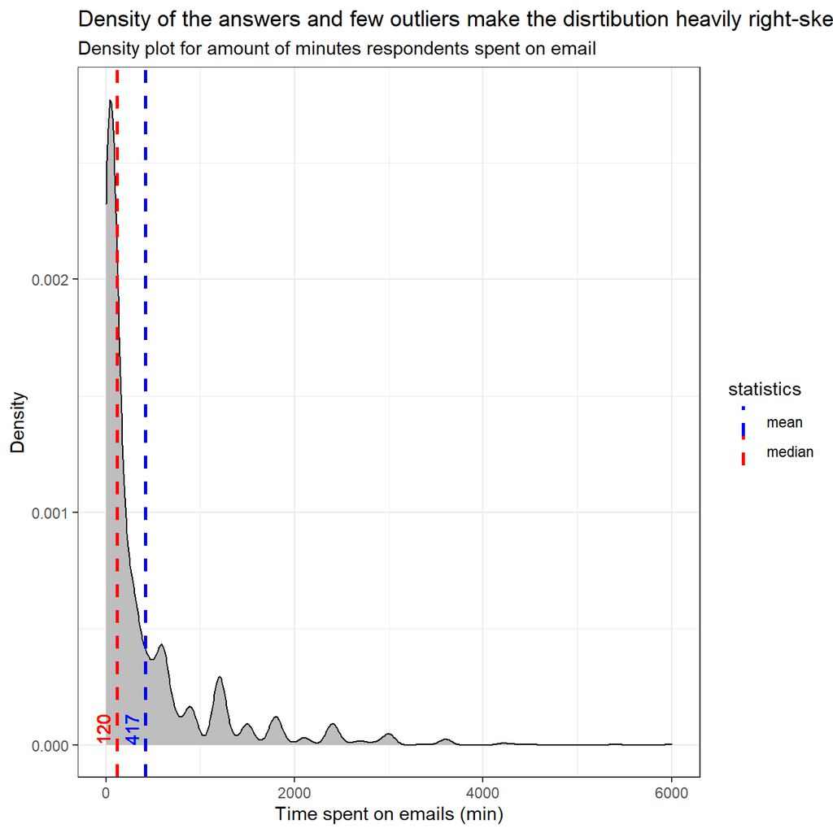

```r
ggplot(email_pop, aes(x = email_in_min))+
  geom_density(fill = "grey") +
  theme_bw()+
  geom_vline(aes(xintercept = mean(email_pop$email_in_min, na.rm = TRUE), color="mean"), size = 1, linetype = 2) +
  geom_vline(aes(xintercept = median(email_pop$email_in_min, na.rm = TRUE), color="median"), size = 1, linetype = 2) +
  scale_color_manual(name = "statistics", values = c(mean = "blue", median = "red")) +
  labs(title = "Density of the answers and few outliers make the disrtibution heavily right-skewed",
       subtitle = "Density plot for amount of minutes respondents spent on email",
       x = "Time spent on emails (min)",
       y = "Density") +
  geom_text(mapping = aes(x = mean(email_pop$email_in_min, na.rm = TRUE),
                          y = 0,
                          label = round(mean(email_pop$email_in_min, na.rm = TRUE),0),
                          hjust = 0, vjust = -0.5, angle=90),colour="blue") +
  geom_text(mapping = aes(x = median(email_pop$email_in_min, na.rm = TRUE),
                          y = 0,
                          label = round(median(email_pop$email_in_min, na.rm = TRUE),0),
                          hjust = 0, vjust = -0.5, angle=90),colour="red") +

  #scale_x_log10() +
  NULL
```

We see that the median is a better choice in this situation while the distribution is skewed. The median is more robust against outliers than the mean.

We use bootstrapping method to find the 95% confidence interval for the mean amount of time Americans spend on email weekly.

```r
library(infer)

set.seed(1234)

point_estimate = mean(email_pop$email_in_min, na.rm = TRUE)

email_pop_ci <- email_pop %>%
  specify(formula = email_in_min ~ NULL) %>%
  generate(reps = 1000) %>%
  calculate(stat = "mean") %>%
  get_ci(type = "se", point_estimate = point_estimate) %>%
  mutate(point_estimate = point_estimate)


email_pop_ci %>%
  mutate(lower_ci = hms::as.hms(lower_ci),
         upper_ci = hms::as.hms(upper_ci),
         point_estimate = hms::as.hms(point_estimate)
         )
```

```
## # A tibble: 1 x 3
##   lower_ci      upper_ci      point_estimate
##   <time>        <time>        <time>
## 1 06'23.246734" 07'30.437923" 06'56.842329"
```

We conclude that the 95% confidence interval goes from 6 hours and 23 minutes up to 7 hours and 30 minutes. This means that we can be 95% percent sure that our interval includes the true population mean.

For instance, if we were to increase our confidence to 99%, we can expect wider confidence interval. If the range of our interval increases, we are more likely to capture the true population mean within our interval.

# 3 Trump’s Approval Margins

```r
# Import approval polls data
approval_polllist <- read_csv(here::here('data', 'approval_polllist.csv'))

# or directly off fivethirtyeight website
# approval_polllist <- read_csv('https://projects.fivethirtyeight.com/trump-approval-data/approval_polllist.csv')

glimpse(approval_polllist)
```

```
## Rows: 14,533
## Columns: 22
## $ president           <chr> "Donald Trump", "Donald Trump", "Donald Trump",...
## $ subgroup            <chr> "All polls", "All polls", "All polls", "All pol...
## $ modeldate           <chr> "8/29/2020", "8/29/2020", "8/29/2020", "8/29/20...
## $ startdate           <chr> "1/20/2017", "1/20/2017", "1/20/2017", "1/21/20...
## $ enddate             <chr> "1/22/2017", "1/22/2017", "1/24/2017", "1/23/20...
## $ pollster            <chr> "Gallup", "Morning Consult", "Ipsos", "Gallup",...
## $ grade               <chr> "B", "B/C", "B-", "B", "B", "C+", "B-", "B+", "...
## $ samplesize          <dbl> 1500, 1992, 1632, 1500, 1500, 1500, 1651, 1190,...
## $ population          <chr> "a", "rv", "a", "a", "a", "lv", "a", "rv", "a",...
## $ weight              <dbl> 0.262, 0.680, 0.153, 0.243, 0.227, 0.200, 0.142...
## $ influence           <dbl> 0, 0, 0, 0, 0, 0, 0, 0, 0, 0, 0, 0, 0, 0, 0, 0,...
## $ approve             <dbl> 45.0, 46.0, 42.1, 45.0, 46.0, 57.0, 42.3, 36.0,...
## $ disapprove          <dbl> 45.0, 37.0, 45.2, 46.0, 45.0, 43.0, 45.8, 44.0,...
## $ adjusted_approve    <dbl> 45.8, 45.3, 43.2, 45.8, 46.8, 51.6, 43.4, 37.7,...
## $ adjusted_disapprove <dbl> 43.6, 37.8, 43.9, 44.6, 43.6, 44.4, 44.5, 42.8,...
## $ multiversions       <chr> NA, NA, NA, NA, NA, NA, NA, NA, NA, NA, NA, NA,...
## $ tracking            <lgl> TRUE, NA, TRUE, TRUE, TRUE, TRUE, TRUE, NA, NA,...
## $ url                 <chr> "http://www.gallup.com/poll/201617/gallup-daily...
## $ poll_id             <dbl> 49253, 49249, 49426, 49262, 49236, 49266, 49425...
## $ question_id         <dbl> 77265, 77261, 77599, 77274, 77248, 77278, 77598...
## $ createddate         <chr> "1/23/2017", "1/23/2017", "3/1/2017", "1/24/201...
## $ timestamp           <chr> "13:38:37 29 Aug 2020", "13:38:37 29 Aug 2020",...
```

```r
# Use `lubridate` to fix dates, as they are given as characters.
```

## 3.1 Create a plot

We calculate the average net approval rate (approve- disapprove) for each week since he got into office. We plot the net approval, along with its 95% confidence interval.

```r
approval_polllist <- approval_polllist %>%
  mutate(net_approval = approve - disapprove,
         date = mdy(enddate),
         year = year(date),
         week = week(date))

Trump_approval_margin <- approval_polllist %>%
  group_by(year, week) %>%
  summarise(mean_net_approval = mean(net_approval),
            sd_net_approval = sd(net_approval),
            count = n(),
            t_critical = qt(0.975, count-1),
            se_net_approval = sd_net_approval/sqrt(count),
            low_net_approval = mean_net_approval - t_critical*se_net_approval,
            high_net_approval = mean_net_approval + t_critical*se_net_approval)
```

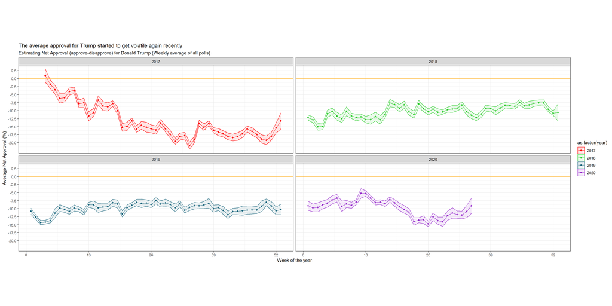

```r
Trump_plot <- Trump_approval_margin %>%
  ggplot(aes(x = week, y = mean_net_approval, color = as.factor(year))) +
  geom_ribbon(aes(ymin = low_net_approval, ymax = high_net_approval, fill = as.factor(year))) +
  geom_line() +
  geom_point() +
  facet_wrap(~year) +
  scale_color_manual(values = c("#FF0000", "#32CD32", "#236B81", "#9932CD", "organge")) +
  scale_fill_manual(values = alpha(c("#FF0000", "#32CD32", "#236B81", "#9932CD"), 0.1)) +
  scale_x_continuous(breaks = c(0, 13, 26, 39, 52)) +
  scale_y_continuous(breaks = seq(-20, 7.5, by = 2.5)) +
  coord_fixed(ratio = 1/1.5) +
  geom_hline(aes(yintercept=0), color = "orange") +
  labs(title = "The average approval for Trump started to get volatile again recently",
       subtitle = "Estimating Net Approval (approve-disapprove) for Donald Trump (Weekly average of all polls)",
       x = "Week of the year",
       y = "Average Net Approval (%)") +
  theme(legend.position = "none") +
  theme_bw()

Trump_plot
```

We facet by year, and add an orange line at zero.

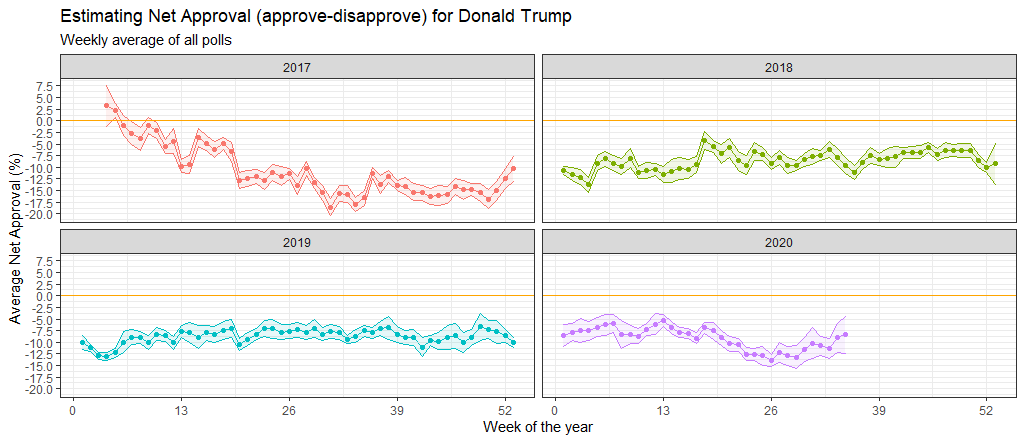

## 3.2 Compare Confidence Intervals for week 15 and week 34 in 2020

We compare the confidence intervals for ‘week 15’ (6-12 April 2020) and ‘week 34’ (17-23 August 2020).

```r
Trump_approval_margin %>%
  filter(week %in% c(15, 34), year == 2020) %>%
  select(c(year, week, low_net_approval, high_net_approval))
```

```
## # A tibble: 2 x 4
## # Groups:   year [1]
##    year  week low_net_approval high_net_approval
##   <dbl> <dbl>            <dbl>             <dbl>
## 1  2020    15            -8.84             -7.36
## 2  2020    34           -12.8              -8.98
```

Based on the results above, in week 34 confidence interval is longer due to a higher standard error which can be due to t-critical value or standard deviation. In both, week 15 and week 34 t-critical values are approximately the same, therefore standard distribution in week 34 is higher indicating poor results. It is then difficult to predict true mean. The reason of this fall might be Trump’s attitude during the beginning of the Coronavirus outbreak.

# 4 Gapminder revisited

We load the Gapminder dataset.

```r
# load gapminder HIV data
hiv <- read_csv(here::here("data","adults_with_hiv_percent_age_15_49.csv"))
life_expectancy <- read_csv(here::here("data","life_expectancy_years.csv"))

# get World bank data using wbstats
indicators <- c("SP.DYN.TFRT.IN","SE.PRM.NENR", "SH.DYN.MORT", "NY.GDP.PCAP.KD")

library(wbstats)

worldbank_data <- read_csv(here::here("data","worldbank_data.csv")) %>%
  select(country,date,SP.DYN.TFRT.IN,SE.PRM.NENR, SH.DYN.MORT, NY.GDP.PCAP.KD)


# get a dataframe of information regarding countries, indicators, sources, regions, indicator topics, lending types, income levels,  from the World Bank API
countries <-  wbstats::wb_cachelist$countries
```

Firstly, we join the three dataframes: life_expectancy, worldbank_data, and HIV

```r
hiv_tidy <- hiv %>%
  pivot_longer(cols=c('1979':'2011'),names_to = "date",values_to = "hiv_percentage")
hiv_tidy$date <- as.numeric(hiv_tidy$date)

life_expectancy_tidy <- life_expectancy %>%
  pivot_longer(cols=c('1800':'2100'),names_to = "date",values_to = "life_exp")
life_expectancy_tidy$date <- as.numeric(life_expectancy_tidy$date)


region_worldbank <- full_join(countries, worldbank_data, by = "country") %>%
  filter(region != "Aggregates")

countries_data <- full_join(region_worldbank, life_expectancy_tidy, by = c("country", "date"))

countries_data <- full_join(countries_data, hiv_tidy, by = c("country", "date")) %>%
  filter(!is.na(region))
```

We use full join within mutating joins because it helps us to keep all values in 3 dataframes and we don’t want to lose any of the values. The main reason why we use full join is that we notice that some of the countries have different names in different dataframe. If we were to use left/right/inner joins, some data of the countries would be eliminated. Then, we generate a scatterplot with a regression line to investigate the relationship between HIV prevalence and life expectancy.

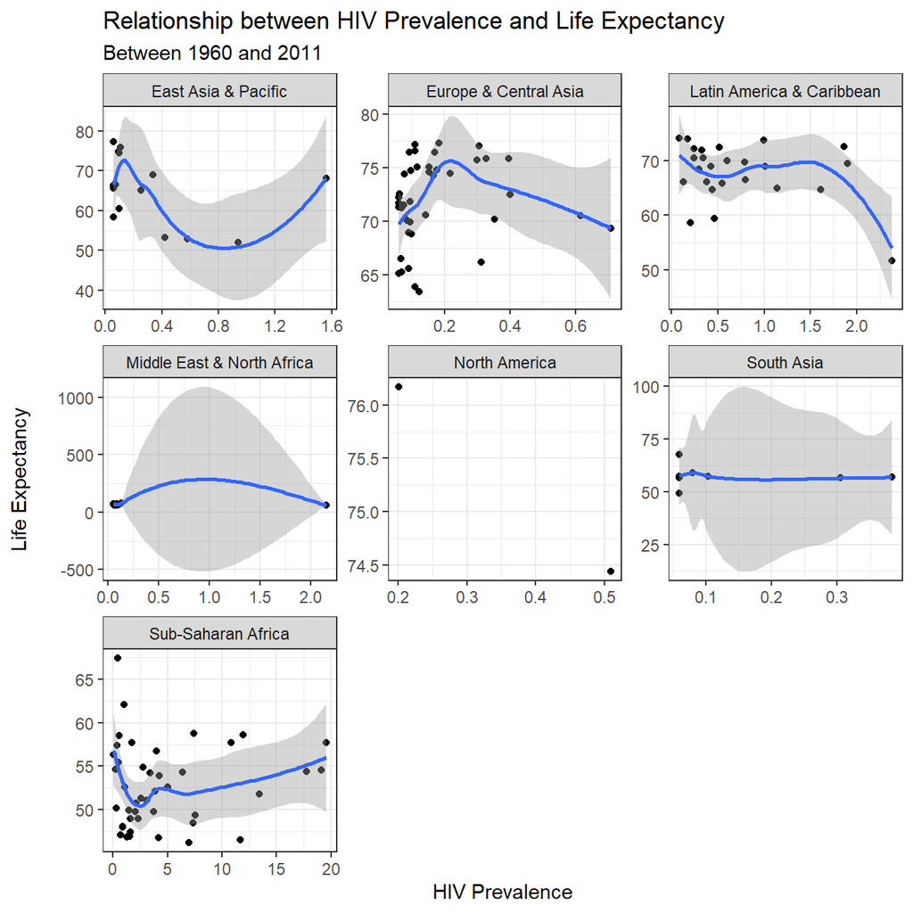

```r
countries_hiv_lifeexp <- countries_data %>%
  filter(date >= 1960, #very few datapoint before 1990
         date <= 2011) %>% #No datapoint for hiv prevalence after 2011
  group_by(country, region) %>%
  summarise(mean_hiv = mean(hiv_percentage, na.rm = TRUE),
            mean_life_exp = mean(life_exp, na.rm = TRUE)) %>%
  na.omit()

  ggplot(countries_hiv_lifeexp, aes(x = mean_hiv, y = mean_life_exp))+
  geom_point()+
  geom_smooth()+
  facet_wrap(~region,scales="free")+ #faceting by countries will make too many plots and it can't show the whole trend
  theme_bw()+
  labs(x = "HIV Prevalence",
       y = "Life Expectancy\n",
       title = "Relationship between HIV Prevalence and Life Expectancy",
       subtitle = "Between 1960 and 2011")
```

We observe that the influence of HIV Prevalence on Life Expectancy varies from region to region. In some regions, such as Europe & Central Asia and Latin America & Caribbean, the lower the HIV Prevalence, the higher the Life Expectancy, which shows that HIV Prevalence is a key factor of Life Expectancy. While in some other regions, such as South Asia and East Asia & Pacific, we can’t see a clear trend, which could be caused by the lack of data in those regions to show the trend.

Then, we generate a scatterplot with a regression line to investigate the relationship between fertility rate and GDP per capita.

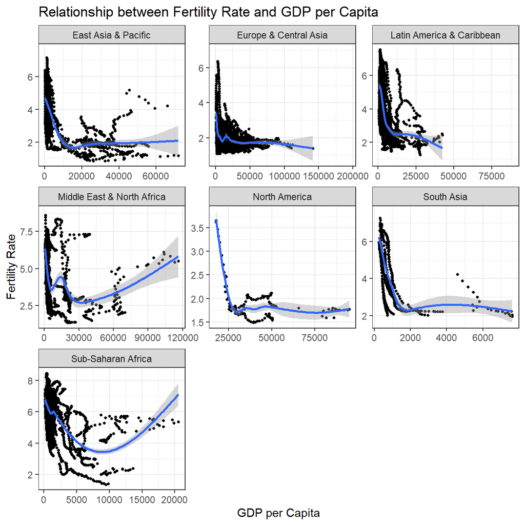

```r
ggplot(countries_data, aes(x = NY.GDP.PCAP.KD, y = SP.DYN.TFRT.IN))+
  geom_point(size = 0.9)+
  geom_smooth()+
  facet_wrap(~region,scale="free")+
  theme_bw()+
  labs(x = "GDP per Capita",
       y = "Fertility Rate",
       title = "Relationship between Fertility Rate and GDP per Capita")
```

We can see a clear negative relationship between GDP per capita and Fertility Rate in most regions, excluding Middle East & North Africa and Sub-Saharan .When GDP per capita increases, the fertility rate decreases. In the those regions being excluded, we observe a u-shape trend. When GDP per capita grows, the fertility rate firstly declines then goes up. There might be specific cultural factors or traditions that support them to give birth to more children when they have ability to raise up them.

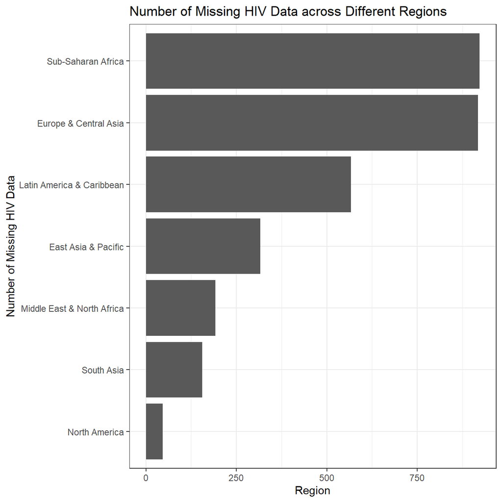

```r
countries_region_na <- countries_data %>%
  group_by(region) %>%
  summarise(missing_hiv = sum(!is.na(hiv_percentage)))

ggplot(countries_region_na, aes(x = missing_hiv, y = reorder(region, missing_hiv)))+
  geom_col()+
  theme_bw()+
  labs(x = "Region",
       y = "Number of Missing HIV Data",
       title = "Number of Missing HIV Data across Different Regions")
```

Then, we investigate how the mortality rate for under 5 changed by region.

Mortality rate for under 5 declined for all 7 regions over the time from 1960.

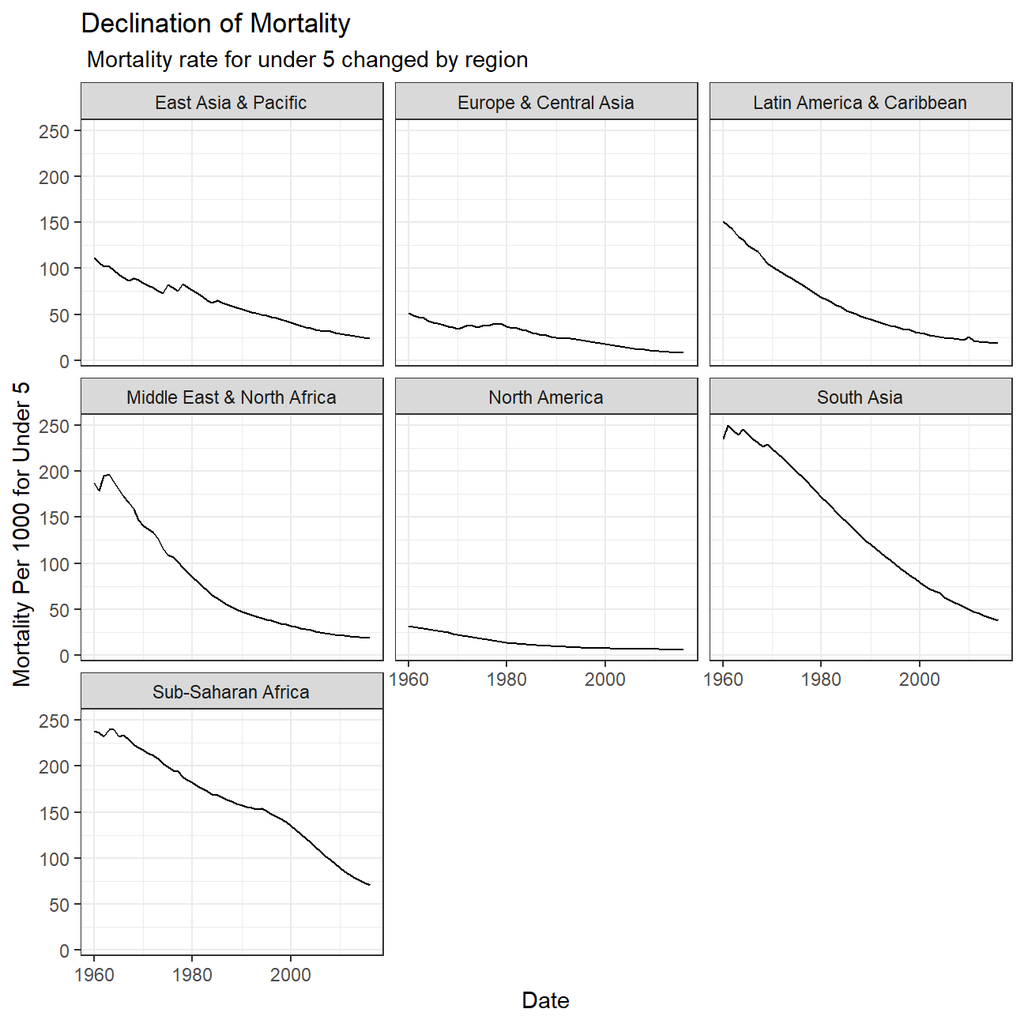

```r
countries_region_mortality <- countries_data %>%
  group_by(region,date) %>%
  summarise(mean_mortality = mean(SH.DYN.MORT, na.rm = TRUE)) #drop NA to find mean, otherwise returns NA

ggplot(countries_region_mortality, aes(x=date,y = mean_mortality ))+
  geom_line()+
  facet_wrap(~region)+
  theme_bw()+
  labs(x="Date",y = " Mortality Per 1000 for Under 5",
       title= "Declination of Mortality",
       subtitle = " Mortality rate for under 5 changed by region")
```

```r
countries_mortality_improvement <- select(countries_data, "country", "date", "region", "SH.DYN.MORT") %>%
  na.omit()%>%
  group_by(country, region) %>%
  mutate(first_rate = first(SH.DYN.MORT),
         last_rate = last(SH.DYN.MORT)) %>%
  summarise(improvement_rate = mean((first_rate - last_rate)/first_rate))
```

## 4.1 Asia top 5 and flop 5 countries in mortality improvement

```r
south_asia <- countries_mortality_improvement %>%
  filter(region == "South Asia") %>%
  arrange(desc(improvement_rate))
south_asia_top5 <-  south_asia %>%
  head(5)
south_asia_tail5 <-  south_asia %>%
  tail(5)
south_asia_top5
```

```
## # A tibble: 5 x 3
## # Groups:   country [5]
##   country    region     improvement_rate
##   <chr>      <chr>                 <dbl>
## 1 Maldives   South Asia            0.970
## 2 Sri Lanka  South Asia            0.916
## 3 Nepal      South Asia            0.892
## 4 Bhutan     South Asia            0.886
## 5 Bangladesh South Asia            0.870
```

```r
south_asia_tail5
```

```
## # A tibble: 5 x 3
## # Groups:   country [5]
##   country     region     improvement_rate
##   <chr>       <chr>                 <dbl>
## 1 Bhutan      South Asia            0.886
## 2 Bangladesh  South Asia            0.870
## 3 India       South Asia            0.830
## 4 Afghanistan South Asia            0.808
## 5 Pakistan    South Asia            0.708
```

## 4.2 East Asia & Pacific top 5 and flop 5 countries in mortality improvement

```r
east_asia_pacific <- countries_mortality_improvement %>%
  filter(region == "East Asia & Pacific") %>%
  arrange(desc(improvement_rate))
east_asia_pacific_top5 <-  east_asia_pacific %>%
  head(5)
east_asia_pacific_tail5 <-  east_asia_pacific %>%
  tail(5)
east_asia_pacific_top5
```

```
## # A tibble: 5 x 3
## # Groups:   country [5]
##   country     region              improvement_rate
##   <chr>       <chr>                          <dbl>
## 1 Korea, Rep. East Asia & Pacific            0.970
## 2 Singapore   East Asia & Pacific            0.943
## 3 Japan       East Asia & Pacific            0.932
## 4 Thailand    East Asia & Pacific            0.932
## 5 China       East Asia & Pacific            0.916
```

```r
east_asia_pacific_tail5
```

```
## # A tibble: 5 x 3
## # Groups:   country [5]
##   country                   region              improvement_rate
##   <chr>                     <chr>                          <dbl>
## 1 Nauru                     East Asia & Pacific            0.534
## 2 Palau                     East Asia & Pacific            0.473
## 3 Korea, Dem. People’s Rep. East Asia & Pacific            0.430
## 4 Micronesia, Fed. Sts.     East Asia & Pacific            0.421
## 5 Brunei Darussalam         East Asia & Pacific            0.293
```

## 4.3 Europe & Central Asia top 5 and flop 5 countries in mortality improvement

```r
europe_central_asia <- countries_mortality_improvement %>%
  filter(region == "Europe & Central Asia") %>%
  arrange(desc(improvement_rate))
europe_central_asia_top5 <-  europe_central_asia %>%
  head(5)
europe_central_asia_tail5 <-  europe_central_asia %>%
  tail(5)
europe_central_asia_top5
```

```
## # A tibble: 5 x 3
## # Groups:   country [5]
##   country  region                improvement_rate
##   <chr>    <chr>                            <dbl>
## 1 Portugal Europe & Central Asia            0.968
## 2 Turkey   Europe & Central Asia            0.954
## 3 Italy    Europe & Central Asia            0.936
## 4 Poland   Europe & Central Asia            0.928
## 5 Finland  Europe & Central Asia            0.926
```

```r
europe_central_asia_tail5
```

```
## # A tibble: 5 x 3
## # Groups:   country [5]
##   country         region                improvement_rate
##   <chr>           <chr>                            <dbl>
## 1 Moldova         Europe & Central Asia            0.751
## 2 Ukraine         Europe & Central Asia            0.731
## 3 Slovak Republic Europe & Central Asia            0.727
## 4 Monaco          Europe & Central Asia            0.649
## 5 Turkmenistan    Europe & Central Asia            0.641
```

## 4.4 Latin America & Caribbean top 5 and flop 5 countries in mortality improvement

```r
latin_america_caribbean <- countries_mortality_improvement %>%
  filter(region == "Latin America & Caribbean") %>%
  arrange(desc(improvement_rate))
latin_america_caribbean_top5 <-  latin_america_caribbean %>%
  head(5)
latin_america_caribbean_tail5 <-  latin_america_caribbean %>%
  tail(5)
latin_america_caribbean_top5
```

```
## # A tibble: 5 x 3
## # Groups:   country [5]
##   country     region                    improvement_rate
##   <chr>       <chr>                                <dbl>
## 1 Chile       Latin America & Caribbean            0.951
## 2 Peru        Latin America & Caribbean            0.932
## 3 El Salvador Latin America & Caribbean            0.921
## 4 Ecuador     Latin America & Caribbean            0.916
## 5 Honduras    Latin America & Caribbean            0.910
```

```r
latin_america_caribbean_tail5
```

```
## # A tibble: 5 x 3
## # Groups:   country [5]
##   country       region                    improvement_rate
##   <chr>         <chr>                                <dbl>
## 1 Venezuela, RB Latin America & Caribbean            0.691
## 2 Guyana        Latin America & Caribbean            0.651
## 3 Suriname      Latin America & Caribbean            0.651
## 4 Bahamas, The  Latin America & Caribbean            0.629
## 5 Grenada       Latin America & Caribbean            0.437
```

## 4.5 Middle East & North Africa top 5 and flop 5 countries in mortality improvement

```r
middle_east_north_africa <- countries_mortality_improvement %>%
  filter(region == "Middle East & North Africa") %>%
  arrange(desc(improvement_rate))
middle_east_north_africa_top5 <- middle_east_north_africa %>%
  head(5)
middle_east_north_africa_tail5 <- middle_east_north_africa %>%
  tail(5)
middle_east_north_africa_top5
```

```
## # A tibble: 5 x 3
## # Groups:   country [5]
##   country              region                     improvement_rate
##   <chr>                <chr>                                 <dbl>
## 1 Oman                 Middle East & North Africa            0.965
## 2 Bahrain              Middle East & North Africa            0.963
## 3 United Arab Emirates Middle East & North Africa            0.961
## 4 Libya                Middle East & North Africa            0.954
## 5 Saudi Arabia         Middle East & North Africa            0.950
```

```r
middle_east_north_africa_tail5
```

```
## # A tibble: 5 x 3
## # Groups:   country [5]
##   country            region                     improvement_rate
##   <chr>              <chr>                                 <dbl>
## 1 Yemen, Rep.        Middle East & North Africa            0.866
## 2 Iraq               Middle East & North Africa            0.851
## 3 Malta              Middle East & North Africa            0.828
## 4 West Bank and Gaza Middle East & North Africa            0.802
## 5 Djibouti           Middle East & North Africa            0.634
```

## 4.6 North America (only two countries) in mortality improvement

```r
north_america <- countries_mortality_improvement %>%
  filter(region == "North America") %>%
  arrange(desc(improvement_rate))
north_america_top5 <-  north_america %>%
  head(5)
north_america_tail5 <-  north_america %>%
  tail(5)
north_america_top5
```

```
## # A tibble: 2 x 3
## # Groups:   country [2]
##   country       region        improvement_rate
##   <chr>         <chr>                    <dbl>
## 1 Canada        North America            0.840
## 2 United States North America            0.777
```

## 4.7 Subsaharan Africa top 5 and flop 5 countries in mortality improvement

```r
subsaharan_africa <- countries_mortality_improvement %>%
  filter(region == "Sub-Saharan Africa") %>%
  arrange(desc(improvement_rate))
subsaharan_africa_top5 <-  subsaharan_africa %>%
  head(5)
subsaharan_africa_tail5 <-  subsaharan_africa %>%
  tail(5)
subsaharan_africa_top5
```

```
## # A tibble: 5 x 3
## # Groups:   country [5]
##   country    region             improvement_rate
##   <chr>      <chr>                         <dbl>
## 1 Cabo Verde Sub-Saharan Africa            0.888
## 2 Mauritius  Sub-Saharan Africa            0.859
## 3 Seychelles Sub-Saharan Africa            0.859
## 4 Malawi     Sub-Saharan Africa            0.842
## 5 Senegal    Sub-Saharan Africa            0.839
```

```r
subsaharan_africa_tail5
```

```
## # A tibble: 5 x 3
## # Groups:   country [5]
##   country                  region             improvement_rate
##   <chr>                    <chr>                         <dbl>
## 1 Central African Republic Sub-Saharan Africa            0.552
## 2 Equatorial Guinea        Sub-Saharan Africa            0.547
## 3 Lesotho                  Sub-Saharan Africa            0.537
## 4 Chad                     Sub-Saharan Africa            0.494
## 5 Somalia                  Sub-Saharan Africa            0.350
```

There is a negative relationship between primary school enrollment rate and fertility rate. The higher the fertility rate is, the lower the primary school enrollment rate. However, the relationship is not obvious in Europe & Central Asia, and North America, probably because the families in these two regions are wealthy enough to afford children’s education, even with more children.

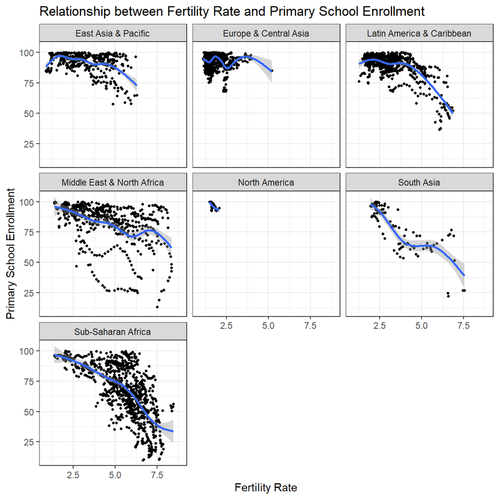

```r
ggplot(countries_data, aes(x = SP.DYN.TFRT.IN, y = SE.PRM.NENR))+
  geom_point(size = 0.9)+
  geom_smooth()+
  facet_wrap(~region)+
  theme_bw()+
  labs(x = "Fertility Rate",
       y = "Primary School Enrollment",
       title = "Relationship between Fertility Rate and Primary School Enrollment")
```

# 5 Challenge 1: CDC COVID-19 Public Use Data

In this section we will look at the [CDC Covid-19 Case Surveillance Data](https://data.cdc.gov/Case-Surveillance/COVID-19-Case-Surveillance-Public-Use-Data/vbim-akqf).

```r
# URL link to CDC to download data
url <- "https://data.cdc.gov/api/views/vbim-akqf/rows.csv?accessType=DOWNLOAD"

covid_data <- vroom(url)%>%
  clean_names()
library(scales)
```

We used the method clean_names() to have proper column descriptions separated by a "_".

We will replicate the two graphs as follows.

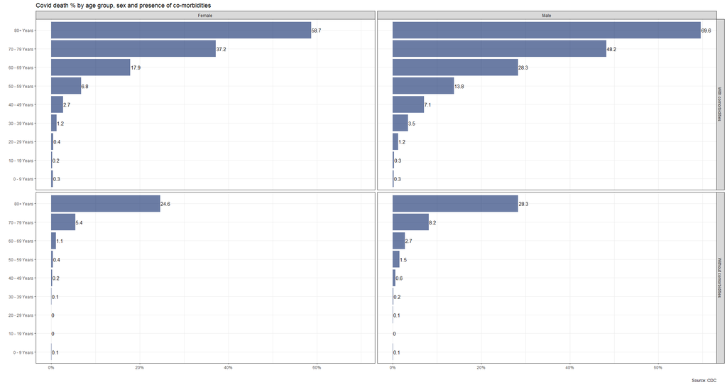

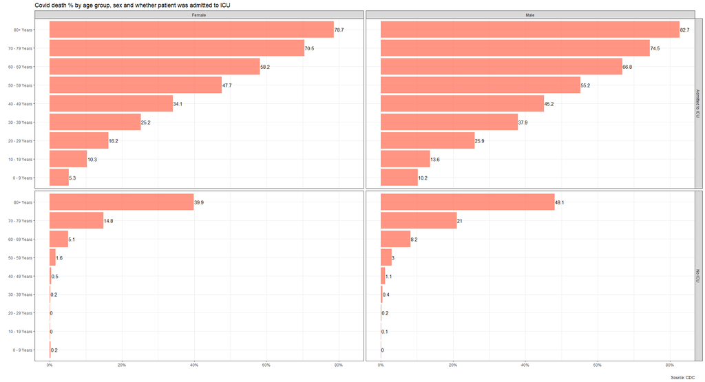

## 5.1 Covid death % by age group, sex and whether the patient had co-morbidities

First we need to select data of interest - sex, age group, whether the patient had co-morbidities and whether the patient died, and clean missing and unknown values.

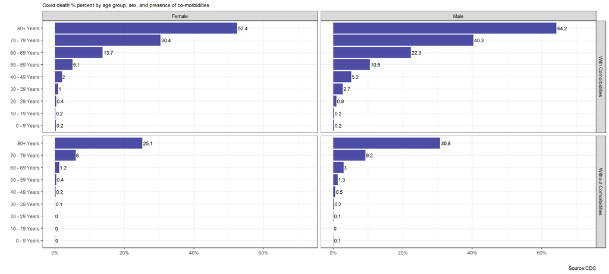

```r
library("scales")
covid_death_rate_comorbidities<-covid_data %>%
  filter(sex %in% c('Male','Female'),!age_group %in% c('Unknown',NA),medcond_yn %in% c('Yes','No'),death_yn %in% c('Yes','No')) %>% #filter for relevant values
  select(sex,age_group,death_yn,medcond_yn) %>%
  group_by(sex,age_group,medcond_yn) %>%
  summarize(death=sum(death_yn=="Yes"),total=n()) %>%
  mutate(death_rate=(death/total*100)) %>%
  select(sex,age_group,medcond_yn,death_rate)

new_labels<-c('Yes'='With Comorbidities','No'='Without Comorbidities')

ggplot(covid_death_rate_comorbidities,aes(x=death_rate,y=age_group))+
geom_col(fill='navy', alpha = 0.7)+
facet_grid(medcond_yn~sex,as.table=FALSE,labeller=labeller(medcond_yn=new_labels))+
  theme_bw()+
  geom_text(aes(label=round(death_rate,digits=1)),hjust=-0.1,size=3)+
  expand_limits(x=c(0,72))+
  scale_x_continuous(labels=label_percent(scale=1))+
  labs(title='Covid death % percent by age group, sex, and presence of co-morbidities',x='',y='',caption='Source:CDC')+
  theme(plot.title=element_text(size=9))
```

We will calculate the Covid death rate here. Finally we produce the plot showing the death rate by age group, sex and whether the patient had comorbidities.

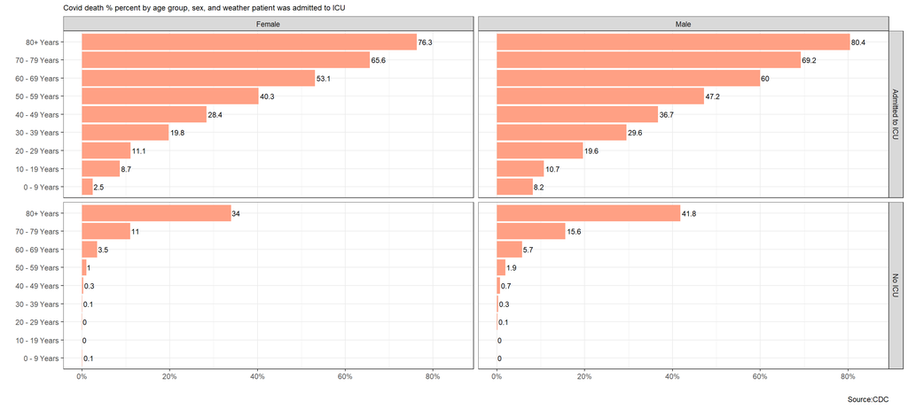

```r
covid_death_rate_icu<-covid_data %>%
  filter(sex %in% c('Male','Female'),!age_group %in% c('Unknown',NA),icu_yn %in% c('Yes','No'),death_yn %in% c('Yes','No')) %>%
  select(sex,age_group,death_yn,icu_yn) %>%
  group_by(sex,age_group,icu_yn) %>%
  summarize(death=sum(death_yn=="Yes"),total=n()) %>%
  mutate(death_rate=(death/total*100)) %>%
  select(sex,age_group,icu_yn,death_rate)

new_labels_icu<-c('Yes'='Admitted to ICU','No'='No ICU')

ggplot(covid_death_rate_icu,aes(x=death_rate,y=age_group))+
geom_col(fill='#ffa084')+
facet_grid(icu_yn~sex,as.table=FALSE,labeller=labeller(icu_yn=new_labels_icu))+
  theme_bw()+
  geom_text(aes(label=round(death_rate,digits=1)),hjust=-0.1,size=3)+
  expand_limits(x=c(0,85))+
  scale_x_continuous(labels=label_percent(scale=1))+
  labs(title='Covid death % percent by age group, sex, and weather patient was admitted to ICU',x='',y='',caption='Source:CDC')+
  theme(plot.title=element_text(size=9))
```

# 6 Challenge 2: Excess rentals in TfL bike sharing

In this section we will look at the Tfl bike sharing data.

```r
url <- "https://data.london.gov.uk/download/number-bicycle-hires/ac29363e-e0cb-47cc-a97a-e216d900a6b0/tfl-daily-cycle-hires.xlsx"

# Download TFL data to temporary file
httr::GET(url, write_disk(bike.temp <- tempfile(fileext = ".xlsx")))
```

```
## Response [https://airdrive-secure.s3-eu-west-1.amazonaws.com/london/dataset/number-bicycle-hires/2020-09-18T09%3A06%3A54/tfl-daily-cycle-hires.xlsx?X-Amz-Algorithm=AWS4-HMAC-SHA256&X-Amz-Credential=AKIAJJDIMAIVZJDICKHA%2F20201004%2Feu-west-1%2Fs3%2Faws4_request&X-Amz-Date=20201004T202802Z&X-Amz-E…
##   Date: 2020-10-04 20:30
##   Status: 200
##   Content-Type: application/vnd.openxmlformats-officedocument.spreadsheetml.sheet
##   Size: 165 kB
## <ON DISK>  C:\Users\Alex\AppData\Local\Temp\RtmpCYCfSD\file29e039715498.xlsx
```

```r
# Use read_excel to read it as dataframe
bike0 <- read_excel(bike.temp,
                   sheet = "Data",
                   range = cell_cols("A:B"))

# change dates to get year, month, and week
bike <- bike0 %>%
  clean_names() %>%
  rename (bikes_hired = number_of_bicycle_hires) %>%
  mutate (year = year(day),
          month = lubridate::month(day, label = TRUE, locale= "English"),
          week = isoweek(day))
```

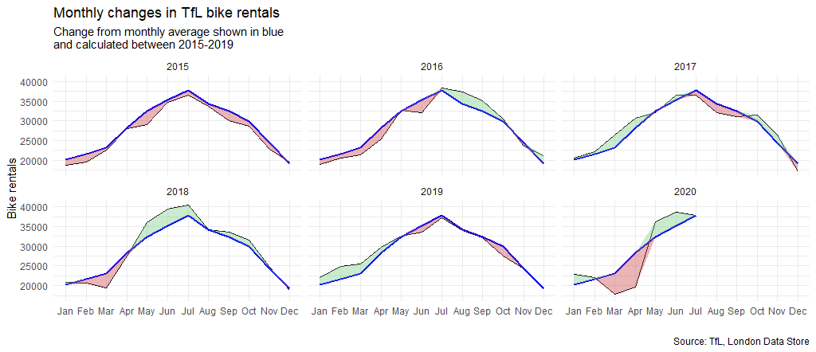

The second one looks at percentage changes from the expected level of weekly rentals. The two grey shaded rectangles correspond to the second (weeks 14-26) and fourth (weeks 40-52) quarters.

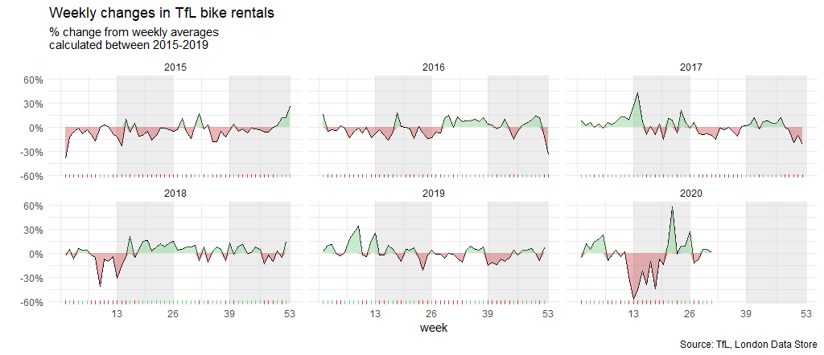

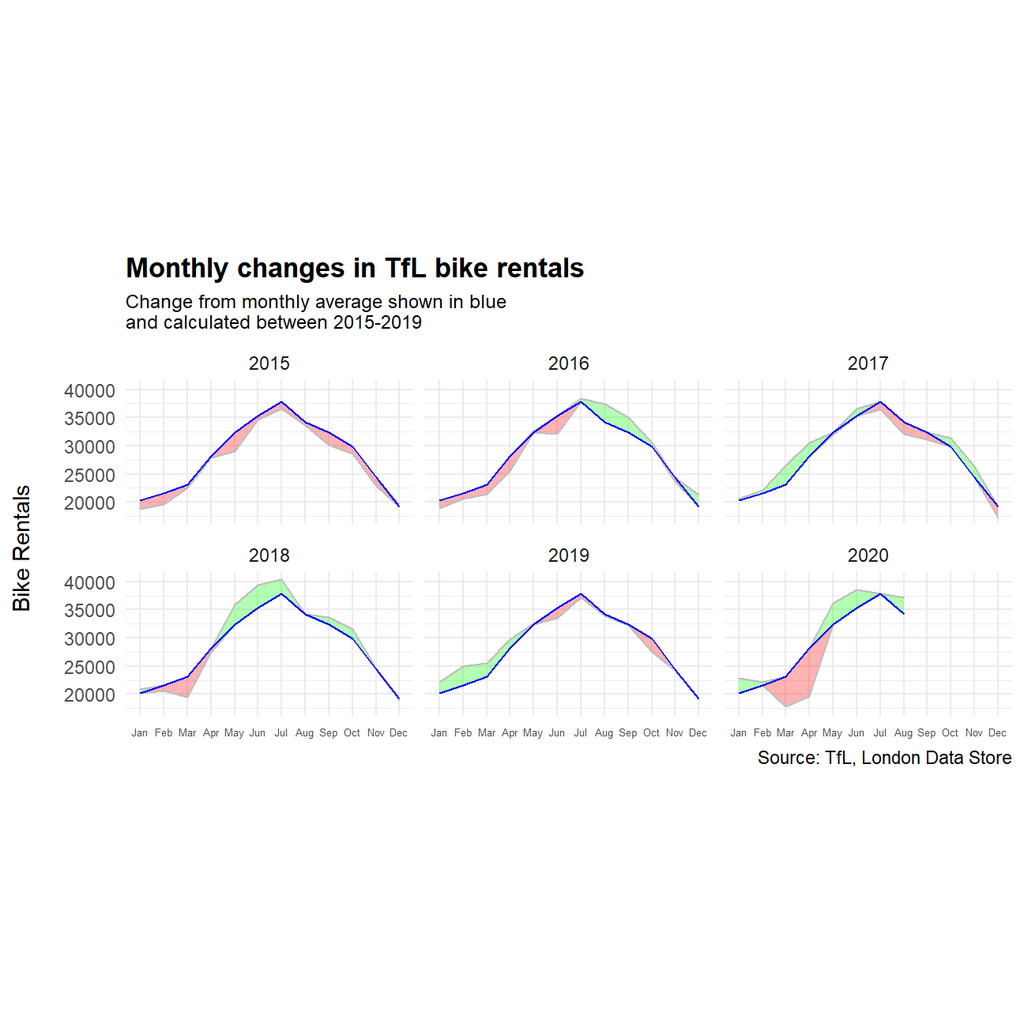

```r
bikes_monthly$month <- as.factor(bikes_monthly$month)



ggplot(data=bikes_monthly, aes(x=month , y=expected_rentals, group=1)) + facet_wrap(~year) +
labs(x=NULL, y="Bike Rentals\n", caption="Source: TfL, London Data Store", title="Monthly changes in TfL bike rentals", subtitle= "Change from monthly average shown in blue \nand calculated between 2015-2019") + theme_minimal(base_family="Arial") +
  theme (plot.title = element_text(size=13, face="bold"), plot.subtitle = element_text(size=9))+
  geom_ribbon(aes(ymin = expected_rentals + if_else(excess_rentals < 0, excess_rentals, 0),
                  ymax = expected_rentals), color ="grey", fill = "red", alpha = 0.3) +
  geom_ribbon(aes(ymin = expected_rentals,
                  ymax = expected_rentals + if_else(excess_rentals > 0, excess_rentals, 0)),color ="grey", fill = "green", alpha = 0.3)+ theme(aspect.ratio=0.5) + theme(axis.text.x= element_text(size=5)) +
  scale_x_discrete(labels=c("Jan", "Feb", "Mar", "Apr", "May", "Jun", "Jul", "Aug", "Sep", "Oct", "Nov", "Dec"))+ geom_line(color="blue")
```

```r
bike_filtered_week <- bike %>%
                  filter(year %in% c(2015: 2020)) %>%
                  group_by(year, week) %>%
                  summarise(avgWeek_filtered_week=mean(bikes_hired))
#Calculate expected number of rentals each week
bike_weekly_average <- bike_filtered_week %>%
                  filter(year %in% c(2015: 2019)) %>%
                  group_by(week) %>%
                  summarise(avgWeek_weekly_average=mean(avgWeek_filtered_week))

#Merge data
bike_joined_full <- left_join(bike_filtered_week, bike_weekly_average, by = "week")

#Calculate the percentage excess rental on each week of the year
bike_joined_full_2 <- bike_joined_full %>%
  mutate(above_avg = (avgWeek_filtered_week - avgWeek_weekly_average)*100/avgWeek_weekly_average)
```

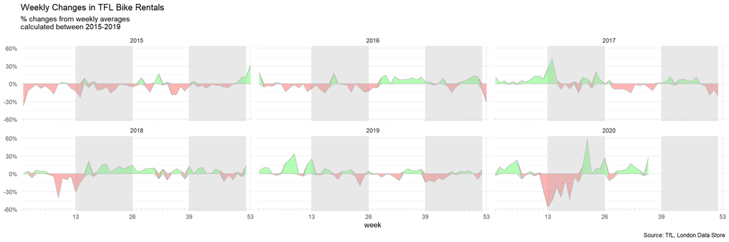

```r
ggplot(bike_joined_full_2, aes(x=week, y=above_avg)) +
  labs(title= "Weekly Changes in TFL Bike Rentals", subtitle="% changes from weekly averages \ncalculated between 2015-2019", x="week", y=NULL, caption="Source: TfL, London Data Store") +
  geom_line(fill="black") +
  theme_minimal() +
  facet_wrap(~year)+
  geom_ribbon(aes(ymin = above_avg - if_else(above_avg < 0, above_avg, 0),
                  ymax = above_avg), color ="grey", fill = "red", alpha = 0.3) +
  geom_ribbon(aes(ymin = above_avg,
                  ymax = above_avg - if_else(above_avg > 0, above_avg, 0)),color ="grey", fill = "green", alpha = 0.3) +
   scale_x_discrete(limits = c(13, 26, 39, 53)) +
  #Shape for quartiles of the year
  geom_rect(xmin=13, xmax=26, ymin=-150, ymax=150, fill="grey", alpha=0.01) +
  geom_rect(xmin=39, xmax=52,ymin=-150, ymax=150, fill="grey", alpha=0.01) +
  geom_rug(sides="b", aes(colour=ifelse(above_avg > 0, "red", "green")), alpha=0.2) +
  theme(legend.position='none') +
  scale_y_continuous(labels = function(x) paste0(x, "%"))
```

For both of these graphs, you have to calculate the expected number of rentals per week or month between 2015-2019 and then, see how each week/month of 2020 compares to the expected rentals. Think of the calculation `excess_rentals = actual_rentals - expected_rentals`.

In our calculation of expected rentals we use mean, as according to the distribution of bikes hired per month there are no clear outliers. Mean allows to capture the whole sample, accounting for absolute values in high-peaked seasons. It results in a more representing calculation of expected number of bikes hired in each period.

# 7 Details

- Who did you collaborate with: Matias, Philipp, Alex, Sena, Shengwei, Linda
- Approximately how much time did you spend on this problem set: 6x8 hours
- What, if anything, gave you the most trouble: Styling the graphs